# Mission 1 — Ames: modéliser le prix

```r
source("../../utils/requirements.R")
library(AmesHousing); library(broom); library(performance); library(car); library(GGally); library(dplyr)
set.seed(123)
ames <- make_ames()
```

## Objectifs

- Réaliser une EDA rapide — identifier les variables candidates
- Construire un modèle de régression linéaire `lm()` avec ≤ 6 prédicteurs pertinents
- Vérifier les diagnostics — résidus, normalité, homoscédasticité, **VIF**
- Interpréter les coefficients $\beta$

## Étapes guidées

### 1) Nettoyage minimal

```r
ames <- ames %>% janitor::clean_names()
```

**Note**

**Réflexion :** Pourquoi est-il important de nettoyer les noms de variables avant de travailler? Quels problèmes cela pourrait-il éviter?

### 2) EDA éclair

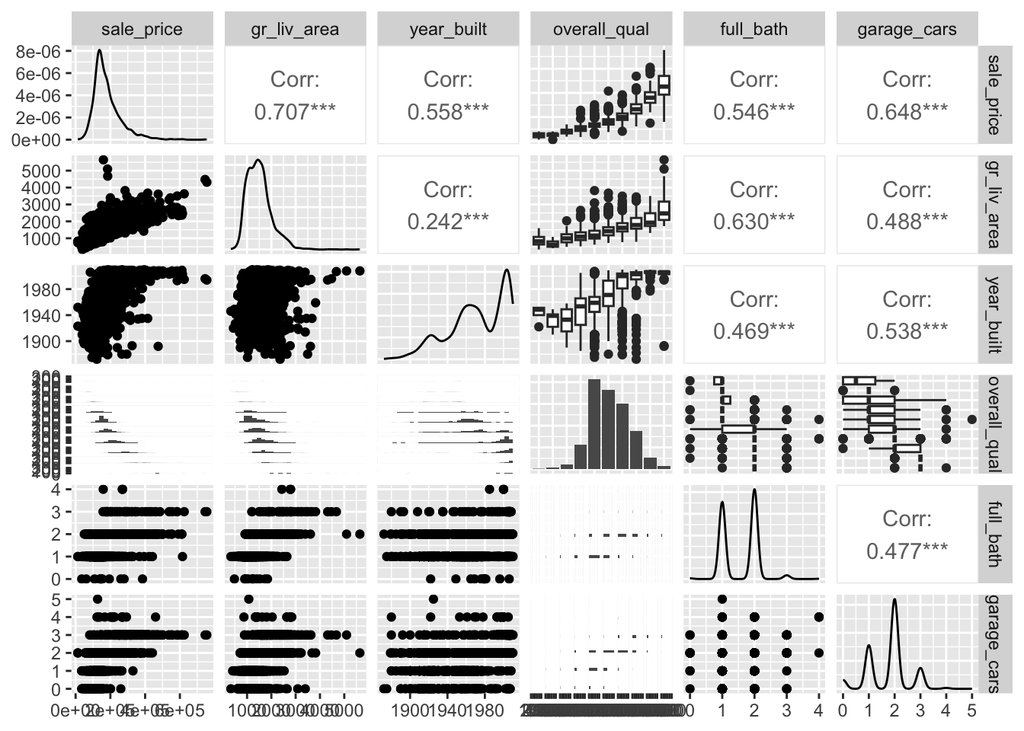

```r
GGally::ggpairs(ames %>% dplyr::select(sale_price, gr_liv_area, year_built, overall_qual, full_bath, garage_cars))
```

**Note**

**À faire (équipe):**

- Quelles variables semblent corrélées avec `sale_price`? Notez les plus pertinentes.
- Quelles relations semblent linéaires? Lesquelles paraissent non linéaires?
- Identifiez au moins une variable qui pourrait nécessiter une transformation.

> Astuce : pensez aux **transformations** si une relation paraît non linéaire (p. ex. `log(sale_price)`).

### 3) Modèle de base

Essayez de construire votre premier modèle à partir de 4 à 6 variables qui vous semblent pertinentes.

```r
mod <- lm(sale_price ~ gr_liv_area + overall_qual + year_built + full_bath + garage_cars, data = ames)
summary(mod)
```

```
Call:
lm(formula = sale_price ~ gr_liv_area + overall_qual + year_built +
    full_bath + garage_cars, data = ames)

Residuals:
    Min      1Q  Median      3Q     Max
-442829  -17192    -901   14649  225492

Coefficients:
                             Estimate Std. Error t value Pr(>|t|)
(Intercept)                -9.190e+05  6.013e+04 -15.284  < 2e-16 ***
gr_liv_area                 5.690e+01  1.897e+00  29.993  < 2e-16 ***
overall_qualPoor            1.965e+04  1.964e+04   1.000 0.317338
overall_qualFair            2.906e+04  1.802e+04   1.612 0.107034
overall_qualBelow_Average   3.808e+04  1.733e+04   2.198 0.028046 *
overall_qualAverage         5.348e+04  1.723e+04   3.105 0.001923 **
overall_qualAbove_Average   6.070e+04  1.727e+04   3.515 0.000446 ***
overall_qualGood            7.858e+04  1.735e+04   4.530 6.12e-06 ***
overall_qualVery_Good       1.230e+05  1.744e+04   7.053 2.17e-12 ***
overall_qualExcellent       2.013e+05  1.773e+04  11.356  < 2e-16 ***
overall_qualVery_Excellent  2.424e+05  1.862e+04  13.022  < 2e-16 ***
year_built                  4.686e+02  2.968e+01  15.789  < 2e-16 ***
full_bath                  -4.496e+03  1.670e+03  -2.692 0.007140 **
garage_cars                 1.318e+04  1.136e+03  11.600  < 2e-16 ***
---
Signif. codes:  0 '***' 0.001 '**' 0.01 '*' 0.05 '.' 0.1 ' ' 1

Residual standard error: 34330 on 2916 degrees of freedom
Multiple R-squared:  0.8162,    Adjusted R-squared:  0.8154
F-statistic: 996.1 on 13 and 2916 DF,  p-value: < 2.2e-16
```

**Note**

**Réflexion :**

- Quels sont les coefficients estimés? Que signifient-ils dans le contexte du prix des maisons?
- Quels prédicteurs sont significatifs? Comment l’interprétez-vous?
- Quelle est la valeur du $R^2$? Est-elle satisfaisante?

### 4) Diagnostics

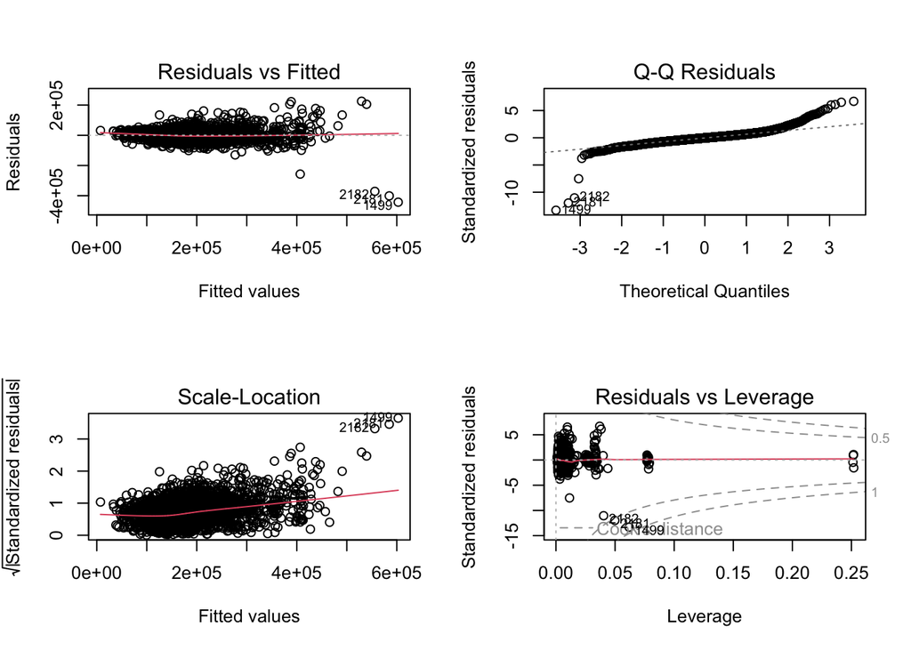

```r
par(mfrow=c(2,2)); plot(mod); par(mfrow=c(1,1))
```

```r
performance::check_collinearity(mod)
```

```
# Check for Multicollinearity

Low Correlation

         Term  VIF   VIF 95% CI adj. VIF Tolerance Tolerance 95% CI
  gr_liv_area 2.29 [2.16, 2.42]     1.51      0.44     [0.41, 0.46]
 overall_qual 2.63 [2.48, 2.79]     1.06      0.38     [0.36, 0.40]
   year_built 2.00 [1.90, 2.12]     1.42      0.50     [0.47, 0.53]
    full_bath 2.12 [2.01, 2.24]     1.46      0.47     [0.45, 0.50]
  garage_cars 1.86 [1.77, 1.96]     1.36      0.54     [0.51, 0.57]
```

```r
car::ncvTest(mod) # test d'homoscédasticité de Breusch-Pagan
```

```
Non-constant Variance Score Test
Variance formula: ~ fitted.values
Chisquare = 4219.156, Df = 1, p = < 2.22e-16
```

**Note**

**Questions de réflexion :**

1. Que remarquez-vous sur le QQ-plot? Les résidus sont-ils approximativement normaux?
2. Y a-t-il des indices de variance non constante? Quelles en seraient les conséquences?
3. Le VIF suggère-t-il de la multicolinéarité?

### 5) Interprétation

- Exemple : $\beta_{gr\_liv\_area}$ indique la variation moyenne du prix pour +1 pi².
- Pour comparer les effets entre variables, testez un **modèle standardisé**.

```r
mod_std <- lm(scale(sale_price) ~ scale(gr_liv_area) + scale(as.numeric(overall_qual)) + scale(year_built) + scale(full_bath) + scale(garage_cars),
 data = ames)
broom::tidy(mod_std)
```

```
# A tibble: 6 × 5
  term                             estimate std.error statistic    p.value
  <chr>                               <dbl>     <dbl>     <dbl>      <dbl>
1 (Intercept)                      5.63e-16   0.00891  6.32e-14 1.000e+  0
2 scale(gr_liv_area)               4.03e- 1   0.0132   3.04e+ 1 9.73 e-177
3 scale(as.numeric(overall_qual))  4.24e- 1   0.0136   3.11e+ 1 2.55 e-183
4 scale(year_built)                1.67e- 1   0.0125   1.33e+ 1 3.21 e- 39
5 scale(full_bath)                -7.63e- 2   0.0127  -6.02e+ 0 1.92 e-  9
6 scale(garage_cars)               1.44e- 1   0.0121   1.19e+ 1 6.12 e- 32
```

**Note**

**Réflexion :**

- Quelle variable a le plus grand effet relatif? Est-ce cohérent avec vos attentes?
- Comment interprétez-vous les coefficients standardisés?
- Y a-t-il des signes inattendus? Comment les expliqueriez-vous?

## Travail d’équipe

1. Quelle variable a l’effet **le plus fort** ? Justifiez via les coefficients standardisés.
2. Y a-t-il des **signes inattendus** ? Proposez une explication.
3. Que raconte le **QQ-plot** des résidus ?
4. Proposez une variable que vous auriez pu inclure mais que vous avez laissée de côté. Pourquoi?

## Discussion collective

- Sélection raisonnée vs. pas à pas (pourquoi éviter l’automatisme aveugle)
- Variables corrélées et VIF: seuils et bons réflexes
- Comment présenter un modèle imparfait à un non-spécialiste?

## Points de discussion — approfondis

- **Justification avec un expert** des variables incluses ou exclues (au-delà des p-valeurs).
- **Stabilité** des coefficients : colinéarité, sous-échantillonnage répété (validation).
- **Éthique & communication** : comment présenter l’incertitude à un public non technique.
- **Reproductibilité** : graine aléatoire, sessionInfo(), versionnage du code.

## Questions bonus

1. Proposez une transformation (log, standardisation, polynomial) pour un prédicteur et justifiez-la.
2. Identifiez un point potentiellement influent et discutez s’il faut l’exclure (et pourquoi).
3. Imaginez un scénario où une variable est très significative statistiquement mais peu pertinente dans la réalité. Que faites-vous?